# Homework_decision_tree

Оксана Владимировна Айзсилниекс

22 05 2017

```r
library(randomForest)
library(ggplot2)
library(dplyr)
library(rpart)
```

# Восстановление возраста по данным метилирования

Данные для этой данной домашней работы мы возьмем из статьи “A novel strategy for forensic age prediction by DNA methylation and support vector regression model”, Cheng Xu et al, Scientific reports 2015. (Статья будет в архиве), где авторы попытались построить предсказатель возраста человека по данным метилирования отдельных CpG sites. Данные будут выглядеть следующим образом:

```
##   Sample Age              Array
## 1    F78  20 Sequenom Massarray
## 2    F79  21 Sequenom Massarray
## 3    F80  22 Sequenom Massarray
## 4    F81  23 Sequenom Massarray
## 5    F82  24 Sequenom Massarray
## 6    F83  25 Sequenom Massarray
```

В табличке “ages.tsv” лежат идентификаторы доноров, возраст, и название array, которым это всё добро сделали.

```
##    Primer Chr                   Position  F78  F79
## X1     P1   1                   43425337 0.24 0.09
## X2     P1   1 43425369;43425373;43425375 0.63 0.25
## X3     P1   1                   43425385 0.69 0.44
## X4     P1   1          43425452;43425460 0.88 0.45
## X5     P1   1                   43425479 0.89 0.43
```

```
## [1] "list"
```

В табличке “methylation.tsv” лежат данные про CpG сайты, где эти сайты на геноме находятся, а что самое главное, доля метилирования каждого сайта у наших доноров. Однако в этой табличке также есть NA-значения, авторы статьи утверждают, что это означает “no methylation detected”, и считают их за 0 (вам я их тоже предлагаю считать за 0).

Чтобы NA заменить на 0, попробуем проделать простой инструментальный такт.

```
## [1] FALSE
```

# Предподготовка данных

Вообще сайтов метилирования там какое-то не очень большое количество (95 сайтов), однако часть из них абсолютно не скоррелирована с возрастом, и наверняка вряд ли поможет нам в решении задачи регрессии. Хочется проделать примерно то же, что проделали авторы статьи – сделать ручками очень простой feature selection. Давайте оставим только те, сайты метилирования, которые наиболее скоррелированы с возрастом.

Переподготовка:

1. Для каждого сайта метилирования, посчитать корреляцию между долей метилирования этого сайта в доноре и возрасте донора.
2. Оставить только 10 самых скоррелированных сайтов. Под самыми скоррелированными мы понимаем абсолютное значение корреляции.

Разделение выборок на тренирующую и валидирующую.

```
## [1] 40 10
```

```
## [1] 10 10
```

### Wrapper_function, that was born out of my feverish mind

```
## [1]  5.079604 11.290006
```

### Оптимизация обучения

Параметры случайного леса Мы будем оптимизировать наш случайный лес по нескольким параметрам (эти параметры, являются аргументами функции randomForest). Напомню для сводки, что пускай NN – количество объектов в тренировочном датасете, MM – количество features в нашем датасете.

[output not shown]

### Займемся оптимизацией количества деревьев

## NTREE

От нас требуется построить график зависимости ошибок от параметра ntree. Ты предлагаешь перебрать ntree в интервале seq(1, 1000, 5), но можно перебрать и более удобные для нас значения: хочется лишь, чтобы начальное значение было достаточно маленьким, а конечное – достаточно большим.

Если всё идет хорошо, то вне зависимости от остальных параметров, которые определяют построение деревьев внутри случайного леса, начиная с какого-то момента, количество деревьев не влияет на результат ни в худшую, ни в лучшую сторону. Необходимо зафиксировать это количество деревьев, и использовать это число до конца выполнения домашней работы.

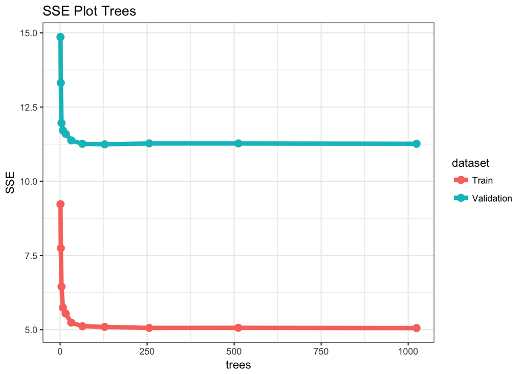

## REPLACE and SAMPSIZE

В этой части задания ты хочешь, чтобы мы зафиксировали значения параметров ntree (из прошлого пункта и оно равно 110), mtry=10 (поскольку мы хотим, чтобы когда мы строим деревья, всем правилам были доступны все features), и nodesize=1 (поскольку мы хотим, чтобы в листовых вершинах оставалось по одному значению).

Ты хочешь, чтобы мы для этих “легко переобучаемых деревьев” оценили эффект переобучения в зависимости от параметров replace и sampsize.

график зависимости ошибки от sampsize (1:40) при replace=F график зависимости ошибки от sampsize (1:40) при replace=T

Посмотрев на эти графики, мне необходимо описать, какая из этих моделей переобучается эффективнее. Это даст мне возможность зафиксировать значения replace и sampsize, для наименее переобученной модели, и использовать эти значения до конца выполнения домашней работы.

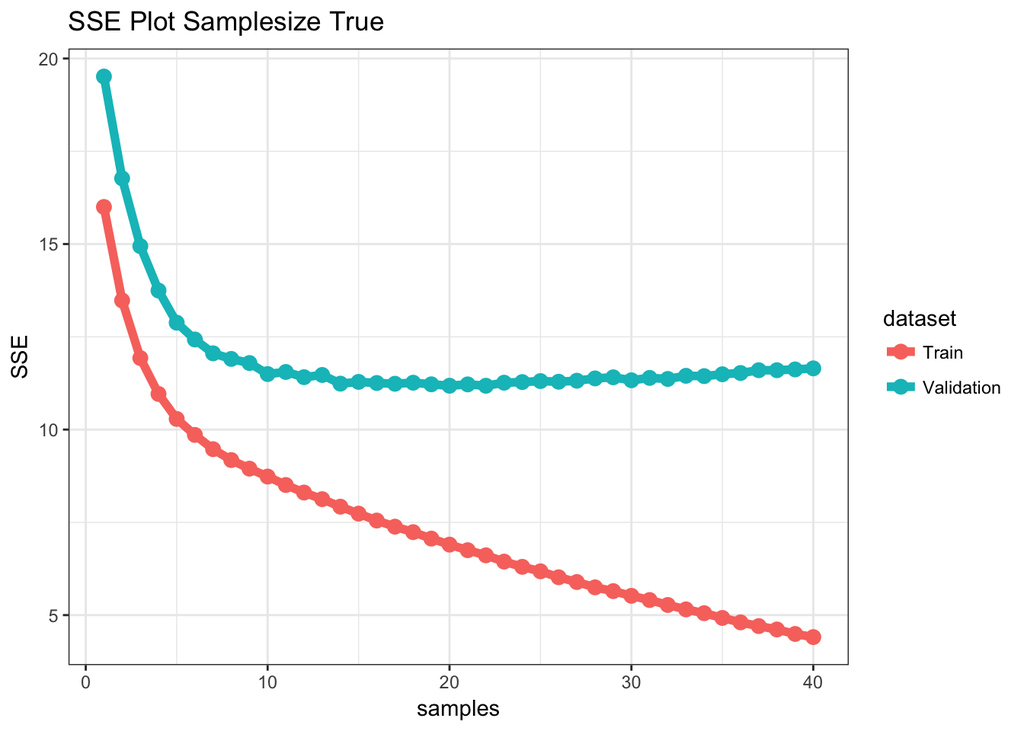

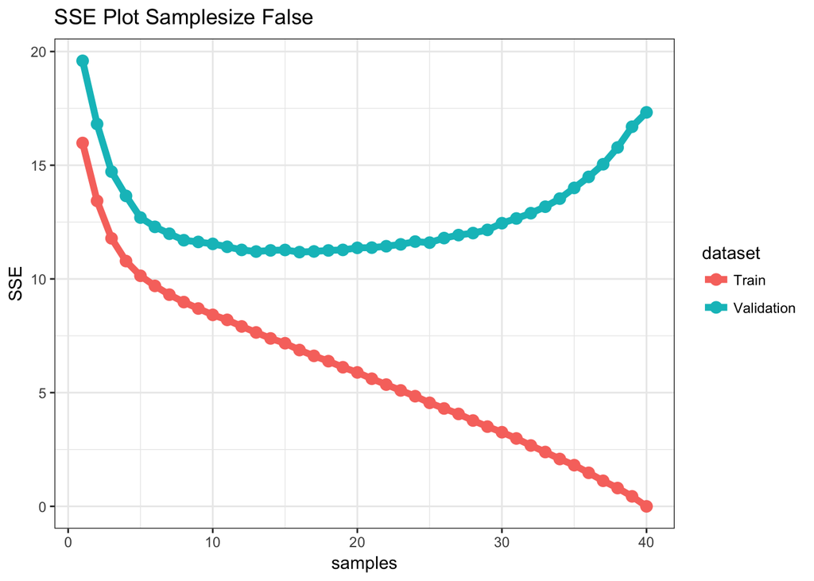

## NODESIZE

В этой части задания ты хочешь, чтобы мы зафиксировали значения параметров ntree (из первого пункта и оно равно 110), mtry=10 (поскольку мы хотим, чтобы когда мы строим деревья, всем правилам были доступны все features), replace и sampsize (взять получившийся на предыдущем этапе результат).

Необходимо построить график зависимости ошибки от nodesize (1:40).

Нужно понять, а есть ли на этом графике переобучение?

Ты предлагаешь нам определить оптимальное значение nodesizе, зафиксировать его и использовать это значение до конца выполнения домашней работы.

Необходимо обратить внимание на то, что здесь стоит смотреть на график “справа налево”, так как при большом nodesize мы считаем decision tree недообученными, а при малом – переобученными.

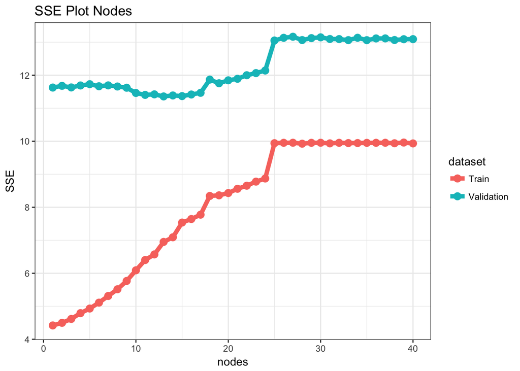

## MTRY

В этой части задания ты хочешь, чтобы мы зафиксировали значения параметров ntree, replace и sampsize, nodesize из предыдущих пунктов, а затем построили график зависимости ошибки от mtry (1:10).

Надо определить оптимальное значение mtry, зафиксировать его и использовать это значение до конца выполнения домашней работы.

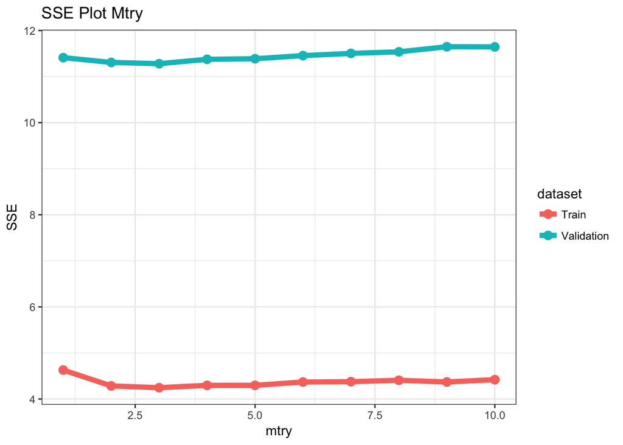

## CROSS VALIDATION

Теперь, после того как мы выбрали значения всех параметров для нашего случайного леса, необходимо выполнить кросс-валидацию. Кросс-валидация – это процесс разбиения датасета на части, и использование по очереди каждой части в качестве тестирующей выборки, а оставшегося – в качестве тренирующей. После этого считается среднее значение ошибки по всем частям, и это выдается как результат.

(Так, ты показываешь нам, как сделать кросс-валидацию на randomForest со значениями по умолчанию: датасет разбивается на 5 частей по 10 человек в каждой части, затем эти части используются по очереди в качестве тестирующих выборок, а оставшееся, - как обучающая. Затем считается ошибка для каждого разбиения и после этого - средняя ошибка).

Подставим в randomForest свои параметры, и посмотрим, как хорошо работает наш random forest по сравнению со случайным лесом по умолчанию.

```r
# our data, matrix 50 donors by 10 methylation sites
dim(for_further_work)
```

```
## [1] 50 11
```

```r
# age of all donors
head(response_age)
```

```
## [1] 20 21 22 23 24 25
```

```r
set.seed(1)

# splitting our dataset into 5 equal parts
cross.validation <- matrix(sample(1:50, 50), nrow=5, ncol=10)
cross.validation
```

```
##      [,1] [,2] [,3] [,4] [,5] [,6] [,7] [,8] [,9] [,10]
## [1,]   14   41    9   18   47   46   31   11   16    22
## [2,]   19   42    7   25   39    1   12   36    6    24
## [3,]   28   29   44   33   49   40   23    2   26    32
## [4,]   43   27   15   13    4   20   38   35   17    45
## [5,]   10    3   48   34   30    8   50    5   21    37
```

С параметрами по умолчанию.

```r
cross.results <- apply(cross.validation, 1, function(test.sample){
  # using each part as testing dataset
  # using rest of the dataset as training dataset
  train.sample <- (1:50)[-test.sample]
  train.data <- for_further_work[train.sample, ]
  train.response <- response_age[train.sample]
  test.data <- for_further_work[test.sample, ]
  test.response <- response_age[test.sample]

  # calculating RMSE for every part and default random forest
  return(wrapper_function(train.data, train.response, test.data, test.response, 100))
})

print(cross.results)
```

```
##          [,1]     [,2]     [,3]     [,4]     [,5]
## [1,] 2.856359 3.070721 3.046835 2.741508 2.969972
## [2,] 6.866520 5.588332 4.999000 7.371281 6.165245
```

```r
print(rowMeans(cross.results))
```

```
## [1] 2.937079 6.198076
```

С подобранными мою в этой работе параметрами.

```r
cross.results_with_params <- apply(cross.validation, 1, function(test.sample){
  # using each part as testing dataset
  # using rest of the dataset as training dataset
  train.sample <- (1:50)[-test.sample]
  train.data <- for_further_work[train.sample, ]
  train.response <- response_age[train.sample]
  test.data <- for_further_work[test.sample, ]
  test.response <- response_age[test.sample]

  # calculating RMSE for every part and default random forest
  return(wrapper_function(train.data, train.response, test.data, test.response, 100, replace=replace, sampsize=nsamp, ntree=ntree, nodesize=nodesize, mtry=nmtry))
})

print(cross.results_with_params)
```

```
##          [,1]     [,2]     [,3]     [,4]     [,5]
## [1,] 2.679342 2.895531 2.943880 2.624768 2.831235
## [2,] 8.159449 6.452178 5.647252 8.441799 6.720688
```

```r
print(rowMeans(cross.results_with_params))
```

```
## [1] 2.794951 7.084273
```

По-моему, мало что поменялось?